# Final Project

Swati Sharma

3/22/2018

```r
packages <-c('foreign','tidyverse','lubridate', 'tm', 'wordcloud', 'downloader', 'jsonlite')
for(i in packages) if(i %in% rownames(installed.packages()) == FALSE) {install.packages(i)}
for(i in packages) suppressPackageStartupMessages(library(i, quietly=TRUE, character.only=TRUE))
```

### Reading in datasets

```r
# importing dataset
# source: https://github.com/bpb27
# thanks to Brendan Brown for the data

url = ("https://github.com/bpb27/trump_tweet_data_archive/blob/master/master_2018.json.zip?raw=true")
download(url, dest="../data/master_2018.json.zip")
unzip("../data/master_2018.json.zip", exdir = "../data")

twitterData2018 <- stream_in(file("../data/master_2018.json"))
```

```
##
 Found 1 records...
 Imported 1 records. Simplifying...
```

```r
twitterData2018 <- flatten(twitterData2018)

url = ("https://github.com/bpb27/trump_tweet_data_archive/blob/master/condensed_2018.json.zip?raw=true")
download(url, dest="../data/condensed_2018.json.zip")
unzip("../data/condensed_2018.json.zip", exdir = "../data")

twitterDataRecent <- stream_in(file("../data/condensed_2018.json"))
```

```
##
 Found 1 records...
 Imported 1 records. Simplifying...
```

```r
twitterDataRecent <- flatten(twitterDataRecent)

twitterData <- read.csv("https://raw.githubusercontent.com/bpb27/political_twitter_archive/master/realdonaldtrump/realdonaldtrump.csv")
```

My biggest challenge with importing the data was unzipping and reading in json files. Initially, I had copy-pasted another url into my code and it would not unzip at all. When I tried manually, it would turn into a cpgz file and then back into a zip file if I tried again. I then learned that I needed the link to the “raw” data and that worked better. Working with the json file was also kind of difficult - I couldn’t view the datasets in r until I “flattened” them. This basically assigns each variable into its own column.

I still haven’t ironed out all the issues with reading in the json files. It seems like there is an incomplete line in the middle of the two files so they stop reading there. This is why the master file only had tweets that date back to 2017; there should actually be tweets from 2009 (when he first opened his twitter account) onwards. This is why I merged the twitterData dataset - its a contains tweets from 2009 to the beginning of 2017. twitterDataRecent only has tweets from the last two months, and twitterData2018 contains tweets from September of 2017 to January of 2018.

I think I’d like to try scraping the data off his twitter myself but that requires a twitter account and I didn’t think it would be full replicable if I tried to do it here. An advantage though, of using Brendan’s data is that he has all of President Trump’s tweets - even if they were deleted off of his account.

### Cleaning data

```r
twitterData2018 <- twitterData2018 %>%
  select(favorite_count, full_text, created_at, retweet_count) %>%                         # removing extra columns
  filter(!is.na(full_text)) %>%                                                            # removing rows without tweets
  separate(created_at, c("Date", "Year"), "\\+0000", remove=TRUE) %>%                      # splitting up strings before and after +0000
  separate(Date, c("Day", "Month", "Date", "Time"), " ", remove=TRUE) %>%                  # splitting up strings by day, month, date, time
  unite("Date", c("Date", "Month", "Year", "Time"), sep = " ", remove=TRUE) %>%            # combine into one date column
  mutate(Date = dmy_hms(Date)) %>%                                                         # creating date object
  arrange(Date) %>%                                                                        # arrange by earliest date
  rename(text = full_text)                                                                 # renaming column to make sure it'll match
                                                                                           # other datasets

twitterDataRecent <- twitterDataRecent %>%
  select(favorite_count, text, created_at, retweet_count) %>%                             # removing extra columns
  filter(!is.na(text)) %>%                                                                # removing rows without tweets
  separate(created_at, c("Date", "Year"), "\\+0000", remove=TRUE) %>%
  separate(Date, c("Day", "Month", "Date", "Time"), " ", remove=TRUE) %>%
  unite("Date", c("Date", "Month", "Year", "Time"), sep = " ", remove=TRUE) %>%
  mutate(Date = dmy_hms(Date)) %>%                                                        # creating dateo bject
  arrange(Date)

# removing retweets
twitterData <- twitterData %>%
  select(-is_retweet, -source, -in_reply_to_screen_name, -id_str) %>%                     # removing extra columns
  separate(created_at, c("Date", "Year"), "\\+0000", remove=TRUE) %>%
  separate(Date, c("Day", "Month", "Date", "Time"), " ", remove=TRUE) %>%
  unite("Date", c("Date", "Month", "Year", "Time"), sep = " ", remove=TRUE) %>%
  mutate(Date = dmy_hms(Date)) %>%                                                        # creating date object
  arrange(Date)
```

One of the challenges in tidying this data was making sure that all columns were following the same naming conventions and making sure the columns contained the same values. The original twitterData2018 contained 100+ columns so readability was difficult. It was also time consuming to convert the original times to actual date objects. I found that splitting up each element into a different column and merging them made the process easier.

### Merging cleaned dataset and splitting up by election periods

```r
twitterData <- rbind(twitterData, twitterData2018, twitterDataRecent)            # append twitterData with other two datasets
twitterData <- twitterData %>% dplyr::distinct(Date, .keep_all = TRUE)           # remove duplicated dates

rm(url, twitterData2018, twitterDataRecent)

beforeRunning <- twitterData %>%                                                 # creating dataset for pre-campaign tweets
  filter(Date < "2015-06-16 00:00:00") %>%                                       # only keep rows from given time period
  mutate(id = row_number())                                                      # adding a column with a tweet id (just in case I need it later)

whileRunning <- twitterData %>%                                                  # creating dataset for tweets during campaign
  filter(Date >= "2015-06-16 00:00:00" & Date < "2017-01-20 09:00:00") %>%
  mutate(id = row_number())

postElection <- twitterData %>%                                                  # creating dataset for post-election tweets
  filter(Date >= "2017-01-20 09:00:00") %>%
  mutate(id = row_number())
```

### Generating wordclouds

#### generating wordcloud for tweets before official candidacy announcement

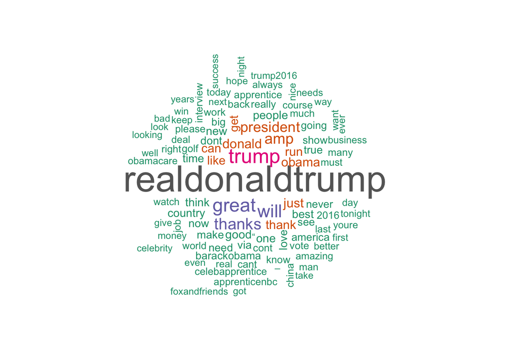

```r
tweetsBefore <- Corpus(VectorSource(beforeRunning$text))                   # creating Corpus(list of input texts)
tweetsBefore <- tm_map(tweetsBefore, removePunctuation)                    # removing punctuation
tweetsBefore <- tm_map(tweetsBefore, tolower)                              # making all words lowercase
tweetsBefore <- tm_map(tweetsBefore, removeWords, stopwords('english'))    # removing english stopwords

# credit for code to build frequency table:
# http://www.sthda.com/english/wiki/text-mining-and-word-cloud-fundamentals-in-r-5-simple-steps-you-should-know

dtm <- TermDocumentMatrix(tweetsBefore)                                    # making table containing words and frequencies
m <- as.matrix(dtm)                                                        # converting to matrix
v <- sort(rowSums(m),decreasing=TRUE)                                      # sort by descending frequency
d <- data.frame(word = names(v),freq=v)                                    # convert to data frame

wordcloud(words = d$word, freq = d$freq, scale = c(3,.7), max.words=100, random.order = FALSE, colors=brewer.pal(8, "Dark2"))
```

#### generating wordcloud for time while he was running

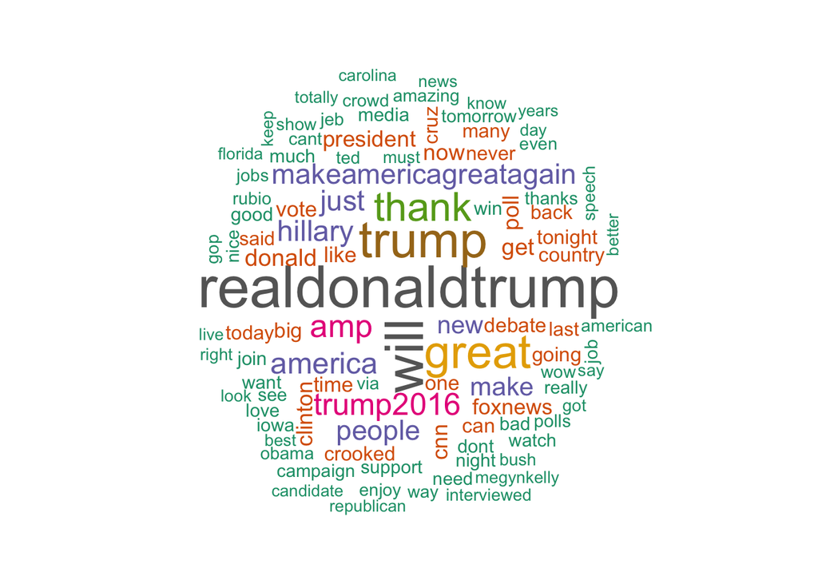

```r
tweetsDuring <- Corpus(VectorSource(whileRunning$text))                   # creating Corpus(list of input texts)
tweetsDuring <- tm_map(tweetsDuring, removePunctuation)                   # removing punctuation
tweetsDuring <- tm_map(tweetsDuring, tolower)                             # making all words lowercase
tweetsDuring <- tm_map(tweetsDuring, removeWords, stopwords('english'))   # removing english stopwords

dtm <- TermDocumentMatrix(tweetsDuring)                                   # making table containing words and frequencies
m <- as.matrix(dtm)                                                       # converting to matrix
v <- sort(rowSums(m),decreasing=TRUE)                                     # sort by descending frequency
d <- data.frame(word = names(v),freq=v)                                   # convert to data frame

wordcloud(words = d$word, freq = d$freq, scale = c(3,.7), max.words=100, random.order = FALSE, colors=brewer.pal(8, "Dark2"))
```

#### generating wordcloud for time after he was elected

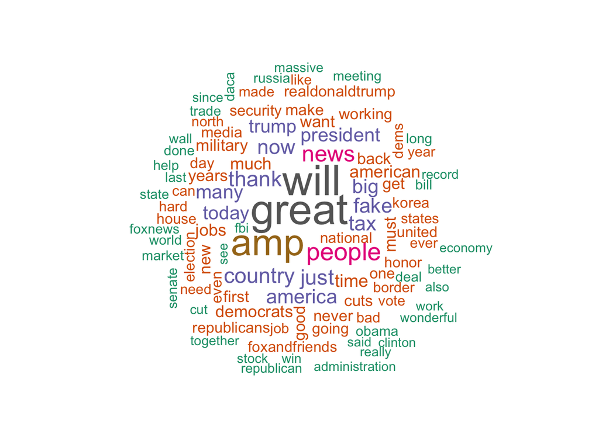

```r
tweetsAfter <- Corpus(VectorSource(postElection$text))                   # creating Corpus(list of input texts)
tweetsAfter <- tm_map(tweetsAfter, removePunctuation)                    # removing punctuation
tweetsAfter <- tm_map(tweetsAfter, tolower)                              # making all words lowercase
tweetsAfter <- tm_map(tweetsAfter, removeWords, stopwords('english'))    # removing english stopwords

dtm <- TermDocumentMatrix(tweetsAfter)                                   # making table containing words and frequencies
m <- as.matrix(dtm)                                                      # converting to matrix
v <- sort(rowSums(m),decreasing=TRUE)                                    # sort by descending frequency
d <- data.frame(word = names(v),freq=v)                                  # convert to data frame

wordcloud(words = d$word, freq = d$freq, scale = c(3,.7), max.words=100, random.order = FALSE, colors=brewer.pal(8, "Dark2"))
```